# Lab 5 Team Document

Mario Lloyd Galvao-Wilson, Justin Park, and Brian Sayre

### Data Input and Libraries

```r
library(tidyverse)
```

```r
library(ggplot2)
library(lubridate)
library(readxl)
acc <- read.csv("https://raw.githubusercontent.com/xdaiISU/ds202materials/master/hwlabs/fars2017/accident.csv", stringsAsFactors = FALSE)

prsn <- read.csv("https://raw.githubusercontent.com/xdaiISU/ds202materials/master/hwlabs/fars2017/person.csv", stringsAsFactors = FALSE)
```

### Question 1

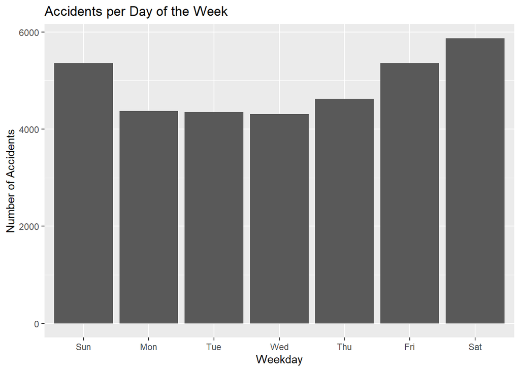

```r
acc$Weekday <- wday(acc$DAY_WEEK, label = T)

acc %>%
  ggplot(aes(Weekday)) + geom_bar() + ylab('Number of Accidents') + ggtitle('Accidents per Day of the Week')
```

The most accidents occur on Fridays, Saturdays, and Sundays. Saturdays have the most accidents of any day of the week, which the number of accidents on Fridays and Sundays are comparable.

### Question 2

```r
fatal <- prsn %>%
  filter(INJ_SEV == 4)
```

### Question 3

```r
q3 <- fatal %>%
  group_by(STATE, MAKE) %>%
  summarise(nf = n())
danger <- q3 %>%
  na.omit() %>%
  group_by(STATE) %>%
  filter(nf == max(nf))
```

### Question 4

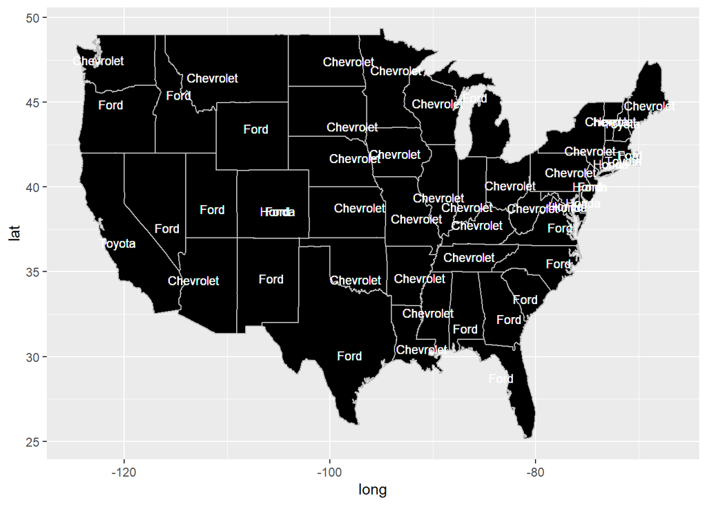

```r
codes <- readxl::read_xlsx("data/state_codes.xlsx")
states <- map_data('state')

codes$'State Name' <- tolower(codes$'State Name')
codes$'State Code' <- as.numeric(codes$'State Code')

labels <- states %>%
   group_by(region) %>%
   summarise(long= mean(long, na.rm = TRUE), lat= mean(lat, na.rm = TRUE))

labels <- left_join(labels, codes, by = c("region" = "State Name"))

labels <- left_join(labels, danger, by = c("State Code" = "STATE"))

labels$MAKE <- factor(labels$MAKE, levels = c(12, 20, 49, 37),
                     labels = c("Ford", "Chevrolet", "Toyota", "Honda"))
states %>% ggplot() +
  geom_polygon(  aes(x=long, y=lat, group=group),
                color="grey", fill="black" ) + geom_text(data=labels, aes(label = MAKE, x=long, y=lat), color="white", size=3)
```

From the map that we made I see a trend where the most dangerous cars in the East tend to be Chevy and as you go more West it starts to shift to Ford. Overall I think there is more Chevy than Ford on this map.

### Question 5

```r
q5 <- inner_join(prsn, acc, by="ST_CASE")
```

### Question 6

```r
q6 <- q5 %>%
  filter(SEX == 1 || SEX == 2) %>%
  group_by(ST_CASE) %>%
  summarise(avgSex = mean(SEX))

q6$sexStr <- ifelse(q6$avgSex == 1, 'Men', ifelse(q6$avgSex == 2, 'Women', 'Both'))

accident <- q6 %>%
  select(ST_CASE, sexStr) %>%
  inner_join( acc, by='ST_CASE')

grouped <- accident %>%
  filter(HOUR <= 24) %>%
  filter(DAY_WEEK != 9) %>%
  group_by(sexStr, HOUR, DAY_WEEK) %>%
  summarise(numAccidents = n()) %>%
  arrange(desc(numAccidents))
```

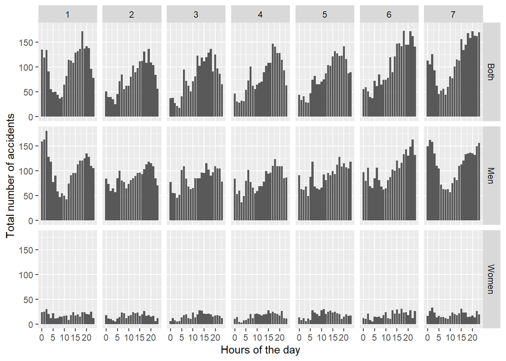

```r
ggplot(grouped,aes(x=HOUR, y=numAccidents)) +
  geom_bar(stat='identity') +
  facet_grid(sexStr~DAY_WEEK) +
  xlab("Hours of the day") +
  ylab("Total number of accidents")
```

In terms of sex I found that both men and women accidents are the most common and men are right behind. You can see that women is much lower than both other categories. In terms of the hour of the day we can see that accidents usually peak later at night and really dip in the mornings.

```r
glc <- read_xlsx("FRPP_GLC_-_United_StATESaPRIL62021.xlsx")
```

```r
states <- map_data('state')
counties <- map_data('county')
```

### Question 7

```r
myvars <- c("STATE", "COUNTY", "FATALS")
fatalities <- acc[myvars]

glc$'State Code' <- as.numeric(glc$`State Code`)
glc$'City Code' <- as.numeric(glc$`City Code`)
glc$'County Code' <- as.numeric(glc$`County Code`)

fatalities <- fatalities %>%
  group_by(STATE, COUNTY) %>%
  summarize(FATALS = sum(FATALS))
```

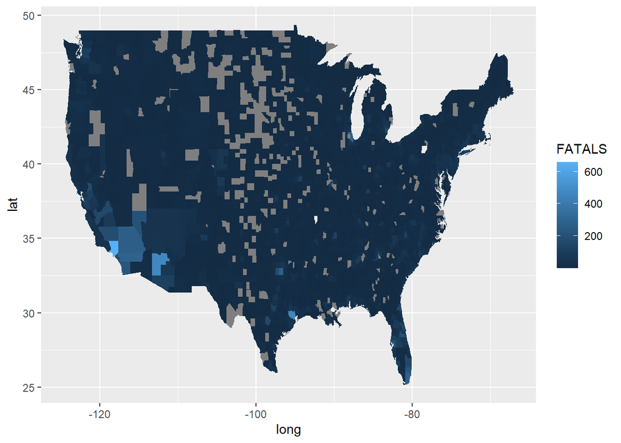

```r
fatalities <- fatalities %>% left_join(glc, by=c('COUNTY' = 'County Code', 'STATE' = 'State Code'))

myvars2 <- c("State Name", "County Name", "FATALS")
fatalities <- fatalities[myvars2]
fatalities <- unique(fatalities)

fatalities$`State Name` <- tolower(fatalities$`State Name`)
fatalities$`County Name` <- tolower(fatalities$`County Name`)

fatalities <- fatalities %>% right_join(counties, by=c('County Name' = 'subregion', 'State Name' = 'region'))

ggplot(fatalities, aes(x=long, y=lat)) +
  geom_polygon(aes(group=group)) +
  geom_polygon(aes(group=group, fill=FATALS))
```

The plot shown mainly has three main colors (Grey, Dark Blue, and Light Blue). The grey areas are places that have no recorded fatal car accidents in the data. The dark blue shows areas with minimal amounts of fatalities and light blue shows the most number of fatal car accidents. The place with the most number of fatalities is Southern California which makes sense since there is a lot of fast car traffic and many highways where fatal car accidents can occur.

### Question 8

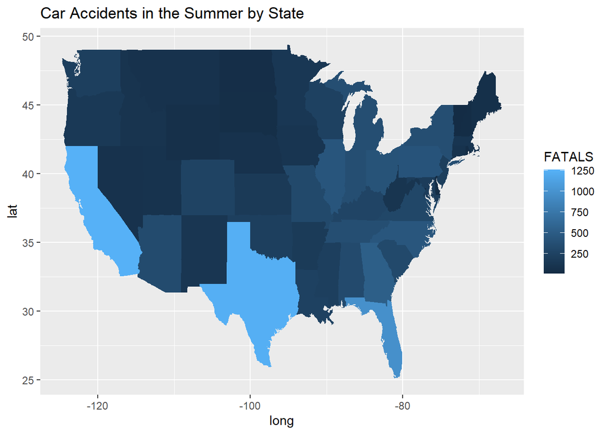

```r
Winter <- acc %>%
          filter(MONTH  < 4 | MONTH > 9)

Summer <- acc %>%
          filter(MONTH > 4 & MONTH < 9)

myvars3 <- c("State Name", "State Code")
glc2 <- glc[myvars3]
glc2 <- unique(glc2)

winterFatal <- Winter %>%
  group_by(STATE) %>%
  summarize(FATALS = sum(FATALS))

summerFatal <- Summer %>%
  group_by(STATE) %>%
  summarize(FATALS = sum(FATALS))

summerFatal <- summerFatal %>% left_join(glc2, by=c('STATE' = 'State Code'))
summerFatal$`State Name` <- tolower(summerFatal$`State Name`)
summerFatal <- summerFatal %>% right_join(states, by=c('State Name' = 'region'))

myvarstwo <- c("STATE", "FATALS", "long", "lat", "group")
summerFatal <- summerFatal[myvarstwo]

ggplot(summerFatal, aes(x=long, y=lat, fill = FATALS)) +
  geom_polygon(aes(group = group)) +
  labs(title = "Car Accidents in the Summer by State")
```

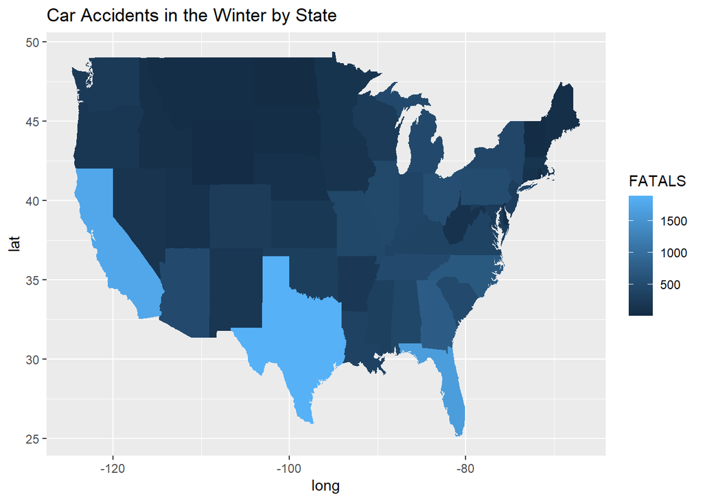

```r
winterFatal <- winterFatal %>% left_join(glc2, by=c('STATE' = 'State Code'))
winterFatal$`State Name` <- tolower(winterFatal$`State Name`)
winterFatal <- winterFatal %>% right_join(states, by=c('State Name' = 'region'))

winterFatal <- winterFatal[myvarstwo]

ggplot(winterFatal, aes(x=long, y=lat, fill = FATALS)) +
  geom_polygon(aes(group = group)) +
  labs(title = "Car Accidents in the Winter by State")
```

I declared winter as October through March and summer as May through August. Winter seems to be more dangerous since there are more car accidents in each state in the Winter. In general whether it is summer or winter, the same states tend to have the most and the least number of fatal car accidents. Texas and California have the most fatal car accidents which makes sense since they are the largest states and there is more traffic. The states with the least number of fatal car accidents are mostly in less populated states such as Montana and Wyoming.